# 타이타닉 실존자 예측 (3)

## To-Do Step

# 1. 라이브러리 임포트

- numpy, pandas, matplotlib, seaborn

```python
import numpy as np
import pandas as pd
import matplotlib.pyplot as plt
import seaborn as sns
%matplotlib inline
```

# 2. 데이터세트 불러오기

- train: 학습데이터세트 불러오기
- test : 테스트데이터세트 불러오기
- gender_submission: 제출하는 결과 파일

> 주의: 데이터세트의 위치 확인하기
> - DataFrame의 info()메서드를 통한 데이터커럼의 타입확인

```python
# csv 데이터 불러오기
train = pd.read_csv('./data/train.csv')
test = pd.read_csv('./data/test.csv')
train.info()
```

# 3. 데이터 가공

## 3.1) 데이터 통합

- train & test data set 결합

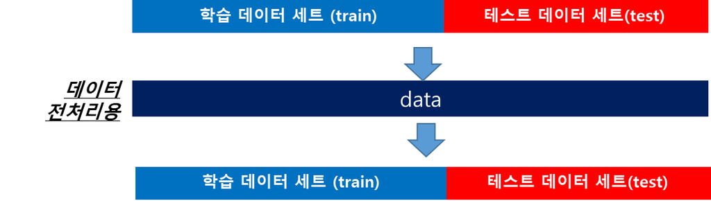

```python
# train과 test 데이터 합치기
data = pd.concat([train, test], sort=False)
```

## 3.2) 결측치 처리

- Embarked, Fare, Age

```python
#결측치 처리
data['Embarked'].fillna(('S'), inplace=True)#Embarked 결측치 - 가장 빈번하게 출현하는 'S' 입력
data['Fare'].fillna(np.mean(data['Fare']), inplace=True)#Fare 결측치 - 평균값 입력
data['Age'].fillna(data['Age'].mean(), inplace=True)#Age 결측치 - 평균값 입력
```

- Cabin 결측치 처리

```python
#Cabin의 결측치에 N 넣기 (None의미)
data['Cabin'].fillna('N',inplace=True)
data.info()
```

```python
#Cabin의 값
print('Cabin값 분포\n', data['Cabin'].value_counts())
```

- **Cabin 변수 변경하기**
  - Cabin의 첫글짜 뽑아내기

```python
# Cabin의 첫글자 뽑아내기

data['Cabin'] = data['Cabin'].str[:1]
print(data['Cabin'].head(3))
```

```python
# seaborn barplot 그리기 -
sns.barplot(x='Cabin',y='Survived',data=data)
```

[output not shown]

```python
data.head()
```

## 3.3) 새로운 변수 생성

- Family, Alone 변수 만들기
- **Family라는 변수를 만들어 보자.**
  - Parch와 SibSp이 모두 '0'이면 혼자 탑승한 고객
  - 그러므로 FamilySize는 1

### Family 변수 생성

```python
data['Family']=data['Parch'] + data['SibSp']+1
```

### IsAlone 변수 생성

- Family가 1일 경우 IsAlone은 '1'

  ```
  data['IsAlone']=0 #초기값 '0'으로 넣기
  data.loc[data['Family']==1,'IsAlone'] = 1 #Family가 1인 경우에  IsAlone 열에 '1'을 입력
  ```

```python
data['IsAlone']=0 #초기값 '0'으로 넣기
data.loc[data['Family']==1,'IsAlone'] = 1 #Family가 1인 경우에  IsAlone 열에 '1'을 입력
```

```python
data['IsAlone']=0 #초기값 '0'으로 넣기
data.loc[data['Family']==1,'IsAlone']=1
```

#### [참고] 판다스에서 일정 행(row)이나 열(column)을 골라내는 방법

- 데이터프레임 인덱싱 방법
- loc: location의 약자
- 행의 라벨이나 boolean array로 인덱싱 하는 방법
- 방법1) df.loc[행 인덱스 값, 열 인덱스 값]
- 방법2) df.loc[bollen조건]
  - 예) df.loc[data['Family']==1] #Family가 1인 경우 출력하라

```python
#Family가 1인 경우 데이터를 보여주세요.

data.loc[data['Family']==1]
```

- Family에 따른 생존여부 살펴보기

  ```
  sns.countplot(x='Family',  hue='Survived', data=data)
  ```

```python
sns.countplot(x='Family',  hue='Survived', data=data)
```

[output not shown]

- IsAlone에 따른 생존여부 특징 보기

  ```
  sns.countplot(x='IsAlone', hue='Survived', data=data)
  ```

```python
sns.countplot(x='IsAlone', hue='Survived', data=data)
```

[output not shown]

## 불필요한 column 삭제

- Name, PassengerId, Ticket
  - axis = 1 열방향 삭제
  - inplace = True 원본에 적용
  - 실제 사용변수 Age, SibSp, Parch, Embarked, Sex, Plcass, Cabin 등

```python
delete_columns = [ 'PassengerId','Name',  'Ticket']

data.drop(delete_columns, axis=1, inplace=True) #지워서 대체
```

```python
data.head(3)
```

## 3.4) 레이블 인코딩

```python
# 범주화 데이터의 수치화
data['Sex'].replace(['male', 'female'], [0, 1], inplace=True)
data['Embarked'] = data['Embarked'].map({'S': 0, 'C': 1, 'Q': 2})
```

```python
# 레이블 인코딩
data['Cabin'] = data['Cabin'].map({'N': 0, 'C': 1, 'B': 2, 'D':3,'E':4,'A':5,'F':6,'G':7,'T':8})
```

## 3.5) One-Hot Encoding

- 대상 변수명(특징량, feature)
  - Embakred (SQC)
  - Pclass (1/2/3)
  - Cabin
- 판다스의 get_dummies()를 이용한 원핫인코딩
  - pd.get_dummies(**data**, prefix=None, prefix*sep='*', dummy_na=False, **columns=None**, sparse=False, drop_first=False, dtype=None)
    - columns : 원핫인코딩 원하는 컬럼
    - prefix의 defualt는 기존 열이름 사용(prefix='Embarked')

```python
# Embarked의 one-hot encoding 및 확인
data = pd.get_dummies(data, columns=['Embarked'])

# Pclass의 one-hot encoding 및 확인
data = pd.get_dummies(data, columns=['Pclass'])

data.head()
```

```python
# Cabin의 one-hot encoding 및 확인
data = pd.get_dummies(data,columns=['Cabin'])
data.head(3)
```

**[정리]**

- 데이터 가공이 끝났으므로 데이터 전처리를 위해 합쳤던 train과 test data set를 다시 분리합니다.

```python
#통합된 데이터 세트(data)를 다시 train과 test 세트로 분리한다.
train = data[:len(train)]
test = data[len(train):]

#이제 기존의 데이터 세트를 정제하고 정리하였으므로 이제부터 분석에 들어감.
```

```python
# train data set 확인
train.head()
```

```python
# test data set 확인
test.head()
```

# 4. 모델구현

## 4.1) 데이터 분할 (data split)

- train data set의 피쳐를 X, 타겟을 y로 분리합니다.

```python
X= train.drop('Survived', axis=1)
y = train['Survived']
```

- train data set를 훈련(train)과 검증(valid)로 나눈다.
- train:valid = 7:3 로 나누어 본다.

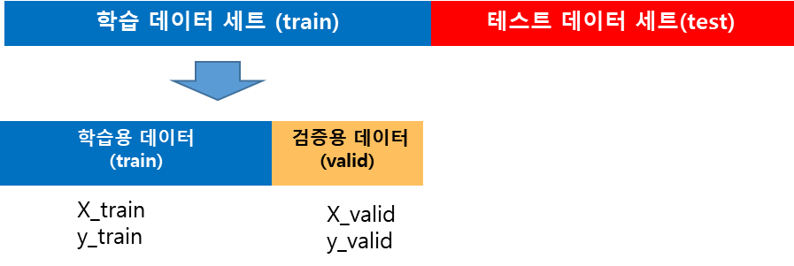

```python
#데이터 분할 (훈련 데이터와 validation 데이터)를 위한 임포트
from sklearn.model_selection import train_test_split


#train data set를 train과 validation data set로 나눈다.

X_train, X_valid, y_train, y_valid = train_test_split(X,y,test_size=0.3, random_state=0)
```

```python
# 데이터 사이즈 확인
print("Size of X_train is:{}\nSize of y_train is:{}\nSize of X_valid is:{}\nSize of Y_valid is:{}\n".format(
    X_train.shape,y_train.shape,X_valid.shape,y_valid.shape))
```

```python
X_train.describe()
```

## 4.2) 머신러닝 알고리즘 적용하기

### 1) LogisticRegression을 이용한 분류

```python
X_valid
```

```python
from sklearn.linear_model import LogisticRegression

lr_clf = LogisticRegression(max_iter=1000)
lr_clf.fit(X_train,y_train)
```

```python
print('정확도(train):{:.3f}'.format(lr_clf.score(X_train,y_train))) #소수점 셋째자리까지 표기
print('정확도(valid):{:.3f}'.format(lr_clf.score(X_valid,y_valid)))
```

[output not shown]

```python
lr_clf.coef_
```

```python
#테스트 데이터 형태 보기
test.head()
```

```python
#  Survived 열을 제외하고 X_test로 저장하기

X_test = test.drop('Survived', axis=1)
y_pred = lr_clf.predict(X_test)
```

### 모델 평가 방법 확장하기

#### 정확도 측정방법 (ppt)

- [방법1] lr_clf.score(X_valid,y_valid)
- [방법2] accuracy_score(y_valid, lr_clf_pred)

**[방법2] 사이킷런의 accuracy_score 사용하는 방법**

- from sklearn.metrics import accuracy_score
- y_val_pre = lr_clf.predict(X_valid)
- print('accuracy score: ', accuracy_score(y_valid, y_val_pre))

--> lr_clf.score(X_valid,y_valid) 와 동일한 값 나옴.

### 2)타 머신러닝 비교

#### 의사결정나무(Decision Tree)

```python
from sklearn.tree import DecisionTreeClassifier
from sklearn.ensemble import RandomForestClassifier
from sklearn.metrics import accuracy_score
```

```python
# 결정트리, Random Forest 사이킷런 Classifier 클래스 생성
dt_clf = DecisionTreeClassifier(random_state=11)
rf_clf = RandomForestClassifier(random_state=11)
```

```python
# DecisionTreeClassifier 학습/예측/평가
dt_clf.fit(X_train , y_train)
dt_pred = dt_clf.predict(X_valid)
print('DecisionTreeClassifier 정확도: {0:.4f}'.format(accuracy_score(y_valid, dt_pred)))
```

[output not shown]

#### 랜덤포레스트 (Random Forest)

```python
# RandomForestClassifier 학습/예측/평가
rf_clf.fit(X_train , y_train)
rf_pred = rf_clf.predict(X_valid)
print('RandomForestClassifier 정확도:{0:.4f}'.format(accuracy_score(y_valid, rf_pred)))
```

[output not shown]

#### 의사결정나무 모델 성능 향상시키기

- DecisionTreeClassifier의 최적 하이퍼 파라미터를 찾기
- GridSearchCV 이용하기 (ppt)
  - Estimator: classifier., regressor 등 모델
  - param_grid: Key+리스트값을 가지는 딕셔너리. 튜닝을 위해 파라미터명과 사용될 여러 마라미터를 지정함.
  - scoring: 예측 성능을 측정할 평가 방법 (우리는 accuracy)
  - cv: 교차검증을 위해 분할되는 학습/테스트 세트 개수
  - refit: default가 Tue. 가장 최적의 하이퍼 파라미터를 찾은 뒤, 입력된 estimator 객체를 해당 하이퍼파라미터로 재학습 시킴.

```python
from sklearn.model_selection import GridSearchCV

#고려할 파라메터들을 입력함.
parameters = {'max_depth':[2,3,5,10], 'min_samples_split':[2,3,5], 'min_samples_leaf':[1,5,8]}

grid_dclf = GridSearchCV(dt_clf, param_grid = parameters, scoring='accuracy', cv=5)
```

```python
#모델 학습시키기
grid_dclf.fit(X_train, y_train)
```

```python
#(추가로 해보기) GridSearchCV 결과 추출해서 보기
scores_df = pd.DataFrame(grid_dclf.cv_results_)
scores_df[['params', 'mean_test_score','rank_test_score']]
```

```python
# Train data set에 대해, 최적 하이퍼 파라미터와 정확도 확인

print('GridSearchCV 최적 하이퍼 파라미터 :',grid_dclf.best_params_ )
print('GridSearchCV 최고 정확도: {0:.4f} :'.format(grid_dclf.best_score_)) #소수점 4자리까지 표시
best_dclf = grid_dclf.best_estimator_
```

```python
#GridSearchCV의 최적 하이퍼 파라미터로 학습된 모델로 예측 및 평가 수행
dpredictions = best_dclf.predict(X_valid)
accuracy = accuracy_score(y_valid, dpredictions)
print('검증 세트에서의 DecisionTreeClassifier 정확도: {0:.4f}'.format(accuracy))
```

[output not shown]

## 5. 모델 적용

```python
#test dataset 상태 보기
test.head()
```

```python
#  Survived 열을 제외하고 X_test로 저장하기
X_test = test.drop('Survived', axis=1)
```

```python
# Logistic Regression 학습/예측/평가
y_pred = lr_clf.predict(X_test)
```

- RandomForestClassifier 선택시 아래 코드 입력

  ```
  y_pred = rf_clf.predict(X_test)
  ```

- DecisionTreeClassifier 선택시 아래 코드 입력

  ```
  y_pred = best_dclf.predict(X_test)
  ```

### 캐글에 제출하기

```python
#기존 제출파일 불러오기
sub = pd.read_csv('./data/gender_submission.csv')
sub.head(3)
```

```python
#기존 파일에 'Survived' 결과 넣기
sub['Survived'] = list(map(int, y_pred)) #int로 y_pred 넣기

# Survived가 수정된 것을 확인하자.
sub.head(3)
```

```python
#sub_LogReg.csv  파일로 저장하기
sub.to_csv('./sub2.csv', index=False)
```

**Good Luck**